## Daniel Losada and Sergio Quintanilla

```r
library(carData) #to load dataset
library(dplyr)
library(MASS)
```

# Exercise 1

### a) LM Standard

```r
model = lm(prestige~ income+education, Duncan)
n = nrow(Duncan)
k = 2 #2 or 3? not 100% sure
y_hat = model$fitted.values
y_bar = mean(Duncan$prestige)
E_hat = model$residuals

F_stat_func = function(y_hat,y_bar,E_hat,n,k){
  numerator = sum(((y_hat - y_bar)^2)/k)
  denominator = sum((E_hat^2)/(n-k-1))
  F_statistic = numerator/denominator
  F_statistic
}
F_stat_func(y_hat,y_bar,E_hat,n,k)
```

```
## [1] 101.2162
```

### b) Bootstrap Pairs

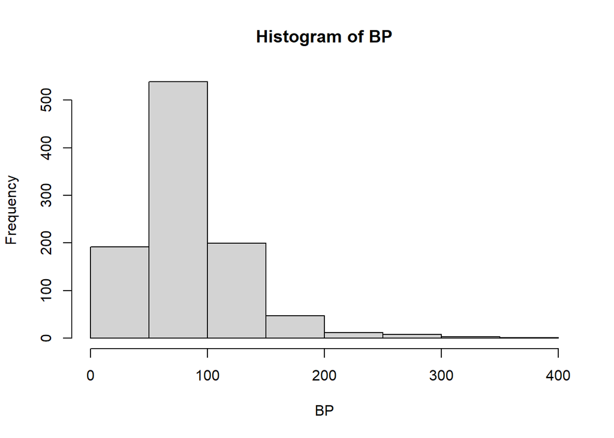

```r
N = 1000 #number of times to repeat the resampling and recalc shit

B_pairs = function(N){
  out = vector(length=N)
  for (i in 1:N){
      samp = sample_n(Duncan,30,replace=T)
      model = lm(prestige~ income+education, samp)
      n = nrow(samp)
      k = 2
      y_hat = model$fitted.values
      y_bar = mean(samp$prestige)
      E_hat = model$residuals
      out[i] = F_stat_func(y_hat,y_bar,E_hat,n,k)
  }
  out
}

BP = B_pairs(N)
hist(BP)
```

```r
sd(BP) / sqrt(length(BP)) #standard error
```

```
## [1] 1.413319
```

### c) Bootsrap Residuals

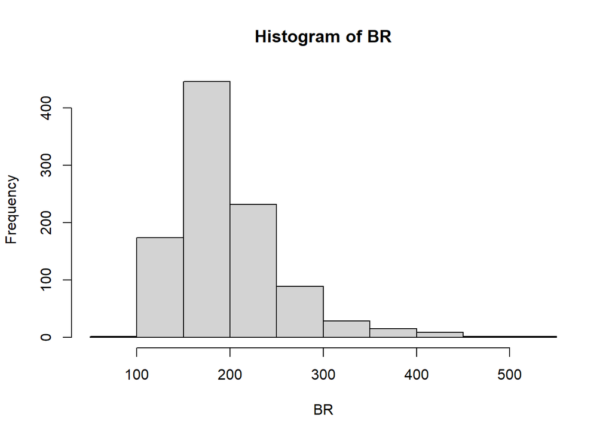

```r
N = 1000 #number of times to repeat the resampling and recalc

B_residuals = function(N){
  out = vector(length=N)
  for (i in 1:N){
      E_samp = sample(E_hat,30,replace=T)
      Y_hat_star = y_hat + E_samp
      out[i] = F_stat_func(Y_hat_star,y_bar,E_samp,n,k)
  }
  out
}

BR = B_residuals(N)
hist(BR)
```

```r
sd(BR) / sqrt(length(BR)) #standard error
```

```
## [1] 1.851912
```

### d) RLM Standard

```r
model = rlm(prestige~ income+education, Duncan)
summary(model)
```

```
##
## Call: rlm(formula = prestige ~ income + education, data = Duncan)
## Residuals:
##     Min      1Q  Median      3Q     Max
## -30.120  -6.889   1.291   4.592  38.603
##
## Coefficients:
##             Value   Std. Error t value
## (Intercept) -7.1107  3.8813    -1.8320
## income       0.7014  0.1087     6.4516
## education    0.4854  0.0893     5.4380
##
## Residual standard error: 9.892 on 42 degrees of freedom
```

```r
n = nrow(Duncan)
k = 2 #2 or 3? not 100% sure
y_hat = model$fitted.values
y_bar = mean(Duncan$prestige)
E_hat = model$residuals
F_stat_func(y_hat,y_bar,E_hat,n,k)
```

```
## [1] 104.1872
```

### RLM with Bootstrap Pairs

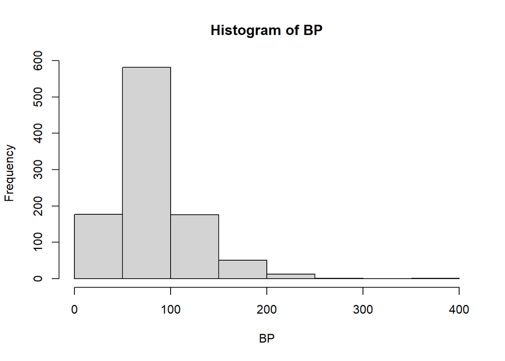

```r
N = 1000 #number of times to repeat the resampling and recalc shit

B_pairs_rlm = function(N){
  out = vector(length=N)
  for (i in 1:N){
      samp = sample_n(Duncan,30,replace=T)
      model = rlm(prestige~ income+education, samp)
      n = nrow(samp)
      k = 2
      y_hat = model$fitted.values
      y_bar = mean(samp$prestige)
      E_hat = model$residuals
      out[i] = F_stat_func(y_hat,y_bar,E_hat,n,k)
  }
  out
}

BP = B_pairs_rlm(N)
hist(BP)
```

```r
sd(BP) / sqrt(length(BP)) #standard error
```

```
## [1] 1.22623
```

### RLM with Bootstrap Residuals

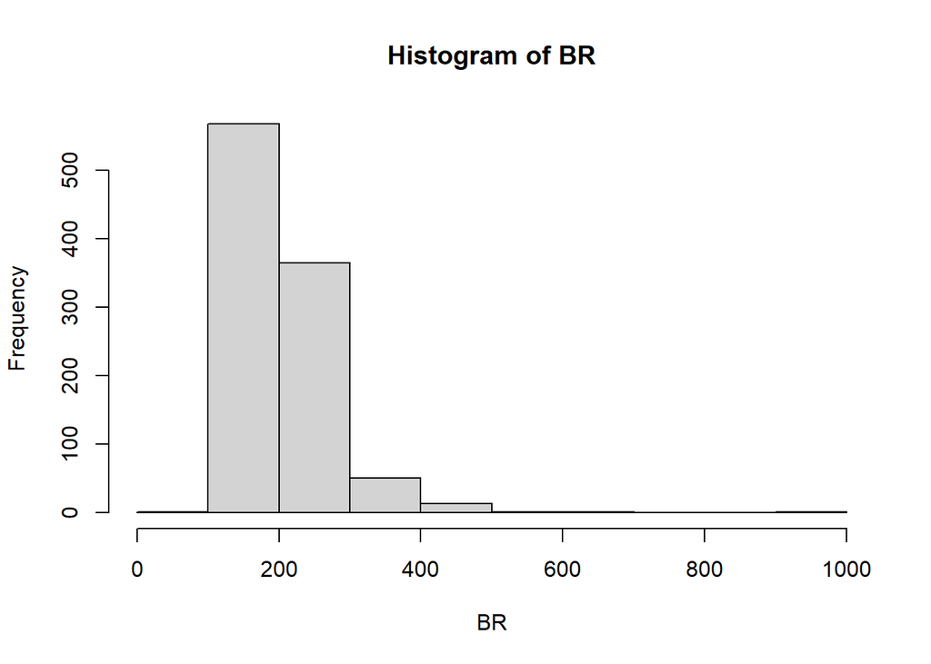

```r
N = 1000 #number of times to repeat the resampling and recalc

B_residuals = function(N){
  out = vector(length=N)
  for (i in 1:N){
      E_samp = sample(E_hat,30,replace=T)
      Y_hat_star = y_hat + E_samp
      out[i] = F_stat_func(Y_hat_star,y_bar,E_samp,n,k)
  }
  out
}

BR = B_residuals(N)
hist(BR)
```

```r
sd(BR) / sqrt(length(BR)) #standard error
```

```
## [1] 2.129495
```

The best performance we saw was in both bootstrap pairs approaches, most notably the rlm models, although both were quite good. This makes sense considering the operation time to accuracy tradeoff we see in most resampling and simulation situations. BP samples generally showed smaller F statistic standard errors and we can see in their histograms they had less spread than the BR samples. However, BR executed far faster than BP samples, for not a huge loss in accuracy. If we needed to work with vastly larger resampling sizes more frequently, BR sampling might be more effective.